# Olink Proteomics Intro analyses in R

Maks Necki

2025-12-16

Installation of required packages

```r
#install.packages("nloptr")
#install.packages("lme4")
#install.packages("pbkrtest")
#install.packages("car")
#install.packages("rstatix")
#install.packages("ggpubr")
#install.packages("OlinkAnalyze")
#install.packages("readxl")
#install.packages("FactoMineR")
#install.packages("factoextra")
```

Loading required libraries

```r
library(dplyr)
```

```r
library(ggplot2)
library(OlinkAnalyze)
library(readr)
library(readxl)
library(FactoMineR)
library(factoextra)
```

Importing dataset and selecting relevant columns for analysis:

```r
df_olink <- OlinkAnalyze::read_NPX("/mnt/dysk_D/Olink_Gdansk/Result-X204SC25109867-Z01-F002-B1-43/Allsamples_prequant_v2.csv")
```

```
##
## Multiple quantification columns detected (NPX, PCNormalizedNPX, Count). NPX will be used for downstream analysis.
```

```
## ℹ Outdated Data Analysis Reference ID and Panel Archive Version combination detected.
```

```
## → Re-export data using Panel Archive Version 1.5.0+ anduse the newest version of the Fixed LOD file when calculating LOD (Version 6+).
```

```
## ! Failure to re-export may result in incorrect PC normalization across lots and Fixed LOD calculations.
```

```r
df_mod <- df_olink %>%
select(SampleID, SampleType, WellID, UniProt, Assay, AssayType, Count, ExtNPX, NPX, PCNormalizedNPX, AssayQC, SampleQC, IntraCV, InterCV, SampleBlockQCWarn, SampleBlockQCFail, BlockQCFail, AssayQCWarn)

head(df_mod)
```

```
## # A tibble: 6 × 18
##   SampleID SampleType WellID UniProt Assay          AssayType Count ExtNPX   NPX
##   <chr>    <chr>      <chr>  <chr>   <chr>          <chr>     <int>  <dbl> <dbl>
## 1 P7W1     SAMPLE     A1     EXT1    Extension con… ext_ctrl  22159      0     0
## 2 K14      SAMPLE     A2     EXT1    Extension con… ext_ctrl  21519      0     0
## 3 K16      SAMPLE     A3     EXT1    Extension con… ext_ctrl  22065      0     0
## 4 K18      SAMPLE     A4     EXT1    Extension con… ext_ctrl  18678      0     0
## 5 P8W2     SAMPLE     A5     EXT1    Extension con… ext_ctrl  19470      0     0
## 6 K10      SAMPLE     A6     EXT1    Extension con… ext_ctrl  17712      0     0
## # ℹ 9 more variables: PCNormalizedNPX <dbl>, AssayQC <chr>, SampleQC <chr>,
## #   IntraCV <dbl>, InterCV <lgl>, SampleBlockQCWarn <int>,
## #   SampleBlockQCFail <int>, BlockQCFail <int>, AssayQCWarn <int>
```

Check data completness:

```r
# If there is no value returned, it means dataset is OK!
OlinkAnalyze:::check_data_completeness(df_olink)
```

Importing validation dataset (don’t know if it will be useful):

```r
df_val <- read_excel("/mnt/dysk_D/Olink_Gdansk/olink-Reveal-validation-data.xlsx", sheet = "Data", skip = 1)
```

Assessing QC status of assays and samples:

```r
table(df_mod$AssayQC)
```

```
##
##  PASS  WARN
## 99072   192
```

```r
table(df_mod$SampleQC)
```

```
##
##  PASS
## 99552
```

Preparing data for plotting and further analyzes:

```r
df_plot <- df_olink %>%
  mutate(QC_Warning = AssayQCWarn == 1)
```

```r
df_plot <- df_plot %>%
  mutate(SampleGroup = NA_character_) %>%
  mutate(SampleGroup = ifelse(grepl("^K", SampleID), "control", SampleGroup)) %>%
  mutate(SampleGroup = ifelse(grepl("^NC", SampleID), "negative control", SampleGroup)) %>%
  mutate(SampleGroup = ifelse(grepl("^PC", SampleID), "plate control", SampleGroup)) %>%
  mutate(SampleGroup = ifelse(grepl("^SC", SampleID), "sample control", SampleGroup)) %>%
  mutate(SampleGroup = ifelse(grepl("^P.*W1$", SampleID), "before treatment", SampleGroup)) %>%
  mutate(SampleGroup = ifelse(grepl("^P.*W2$", SampleID), "after 1 month treatment", SampleGroup)) %>%
  mutate(SampleGroup = ifelse(grepl("^P.*W3$", SampleID), "after 3 month treatment", SampleGroup)) %>%
  mutate(SampleGroup = ifelse(is.na(SampleGroup), "other", SampleGroup))
```

Visualizing distribution of NPX values for our samples:

```
## 2 assay(s) exhibited assay QC warning. For more information see the AssayQC column.
```

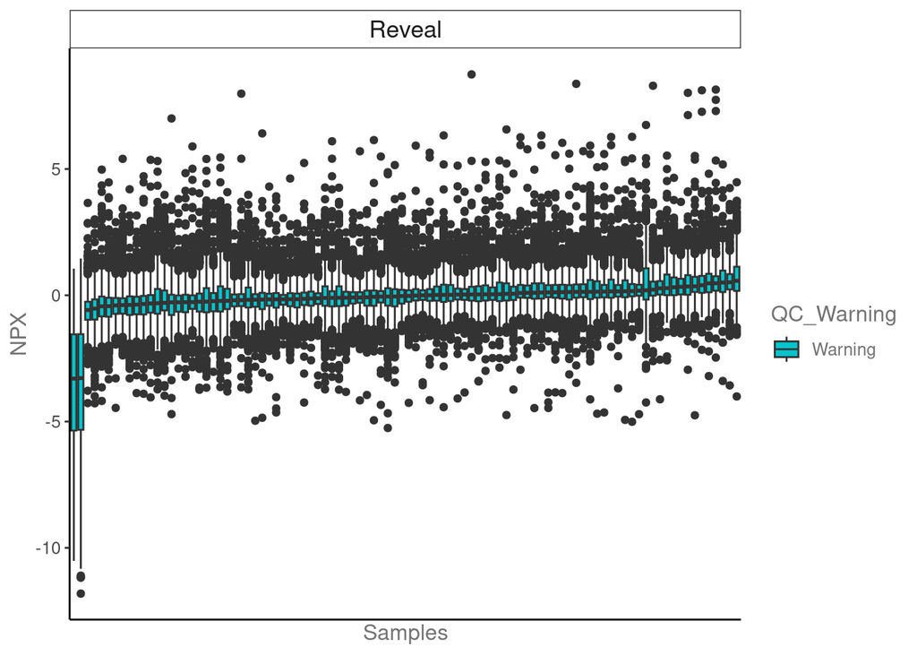

```r
olink_dist_plot(df_plot %>% filter(Panel == 'Reveal')) +
theme(axis.text.x = element_blank(), axis.ticks.x = element_blank()) +
scale_fill_manual(values = c('turquoise3', 'red'))
```

Visualising potential outliers by IQR vs. sample median:

```
## 2 assay(s) exhibited assay QC warning. For more information see the AssayQC column.
```

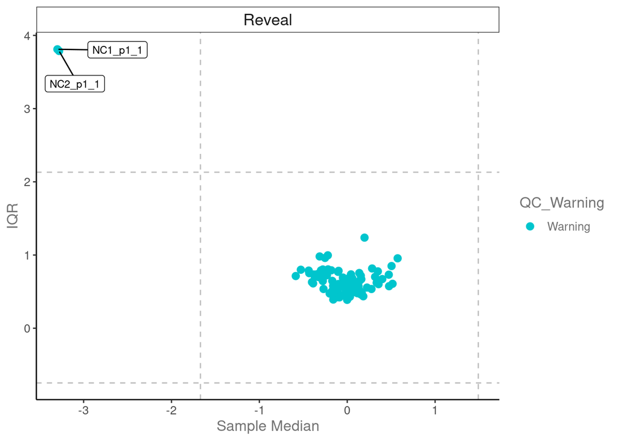

```r
olink_qc_plot(df_plot %>% filter(Panel == 'Reveal')) +
  scale_color_manual(values = c('turquoise3', 'red'))
```

As wee see, all samples pass QC in terms of NPX distribution. First samples seen on plot above were flagged as warnings but they were controls. Nevertheless, to be 1000% save we will filter our dataset to include only samples and assays that passed QC:

```r
df_bio <- df_plot %>%
  filter(AssayType == "assay")

df_qc <- df_bio %>%
  dplyr::filter(SampleQC == "PASS", AssayQC == "PASS")

dim(df_qc); sum(is.na(df_qc$NPX))
```

```
## [1] 99072    32
```

```
## [1] 0
```

Checking wether ExtNPX, NPX and PCNormalizedNPX distributions are normal:

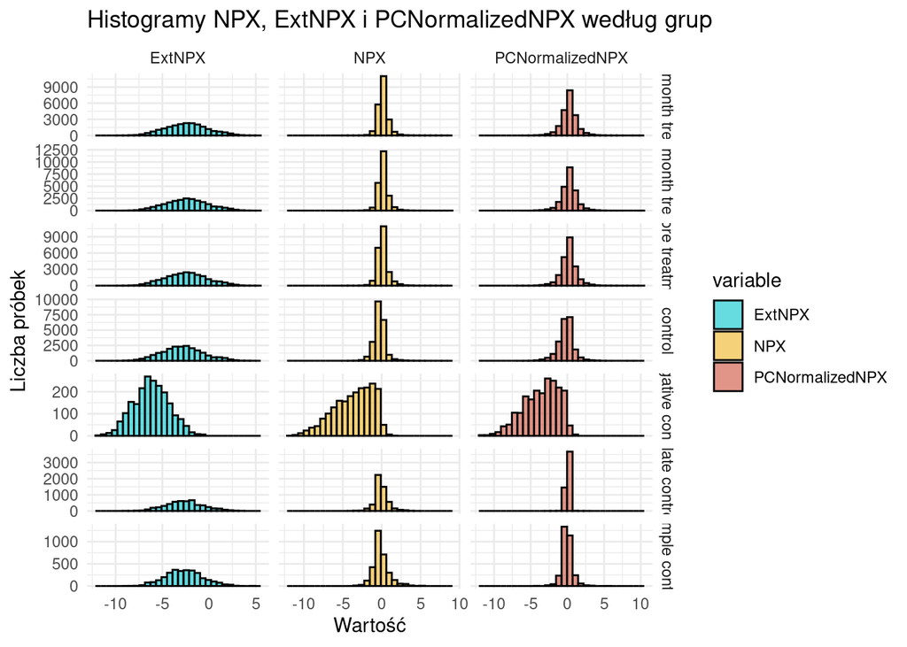

```r
library(tidyr)

# Tworzymy df_long z kolumną SampleGroup
df_long <- df_qc %>%
  select(SampleGroup, NPX, ExtNPX, PCNormalizedNPX) %>%
  pivot_longer(cols = c(NPX, ExtNPX, PCNormalizedNPX), names_to = "variable", values_to = "value")

# Rysujemy histogramy dla każdej zmiennej i grupy
ggplot(df_long, aes(x = value, fill = variable)) +
  geom_histogram(bins = 30, alpha = 0.6, position = "identity", color = "black") +
  facet_grid(SampleGroup ~ variable, scales = "free") +  # osobne wiersze dla grup
  theme_minimal() +
  labs(title = "Histogramy NPX, ExtNPX i PCNormalizedNPX według grup", x = "Wartość",y = "Liczba próbek") +
  scale_fill_manual(values = c("turquoise3", "goldenrod2", "tomato3"))
```

Selecting columns for analyzes, now we have samples as rows and proteins as columns:

```r
df_matrix <- df_qc %>%
    select(SampleID, UniProt, NPX) %>%
    tidyr::pivot_wider(names_from = UniProt, values_from = NPX)

head(df_matrix)
```

```
## # A tibble: 6 × 1,033
##   SampleID  Q7Z7G0 P00519  P09110  P16112   Q9BYF1  P24666 P15309  Q9NPH0 P26436
##   <chr>      <dbl>  <dbl>   <dbl>   <dbl>    <dbl>   <dbl>  <dbl>   <dbl>  <dbl>
## 1 P7W1      0.431  -0.447  0.0244  0.0651  0.198   -1.19   -0.311  0.245  -0.459
## 2 K14      -0.943  -0.948 -1.04   -0.0889 -0.498    0.760  -0.184  0.231  -0.752
## 3 K16      -1.11   -1.06  -0.868  -0.0991 -0.634    0.0806  0.307  0.159  -0.265
## 4 K18      -0.751  -0.241 -0.160   0.0707 -0.243    0.479  -0.470  0.581  -0.544
## 5 P8W2      0.0722  0.986 -0.200   0.128   0.0448   0.510  -0.733  0.0137  0.276
## 6 K10      -0.326  -1.07   0.142  -0.518   0.00506  0.169  -0.714 -0.133  -0.630
## # ℹ 1,023 more variables: P37023 <dbl>, Q96HD9 <dbl>, P00813 <dbl>,
## #   O43184 <dbl>, Q13444 <dbl>, Q9P0K1 <dbl>, O75077 <dbl>, P78325 <dbl>,
## #   Q9UHI8 <dbl>, Q8TE58 <dbl>, Q6UY14 <dbl>, O14514 <dbl>, O60242 <dbl>,
## #   Q14246 <dbl>, Q9BY15 <dbl>, Q86Y34 <dbl>, P08319 <dbl>, P35318 <dbl>,
## #   P30566 <dbl>, Q8TED9 <dbl>, Q8N4X5 <dbl>, O95994 <dbl>, O00253 <dbl>,
## #   Q09666 <dbl>, Q8IVF2 <dbl>, O95433 <dbl>, P55008 <dbl>, Q9Y2D5 <dbl>,
## #   O43823 <dbl>, Q96B36 <dbl>, P31751 <dbl>, Q9Y243 <dbl>, P30838 <dbl>, …
```

We will do PCA with names of samples on a plot (to spot potential outliers with ease this way):

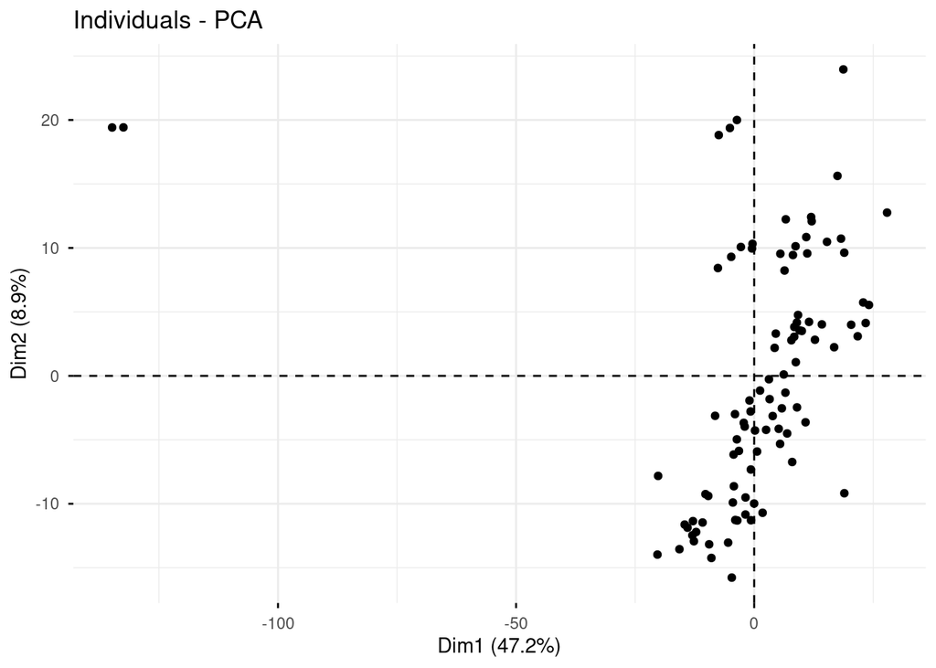

```r
df_matrix2 <- df_matrix
rownames(df_matrix2) <- df_matrix2$SampleID # we must set rownames to sample IDs to visualize straightly them on PCA plot
pca_res_2 <- PCA(df_matrix2[,-1], scale.unit = TRUE, graph = FALSE)
rownames(pca_res_2$ind$coord) <- df_matrix2$SampleID

fviz_pca_ind(pca_res_2, geom.ind = "point", label = "all",repel = TRUE)
```

As we can see, there are no obvious outliers in our dataset. The most two estreme points are two negative controls (which is expected). Here’s another way of visualizing potential outliers using OlinkAnalyze function:

```
## 0 assay(s) exhibited assay QC warning. For more information see the AssayQC column.
```

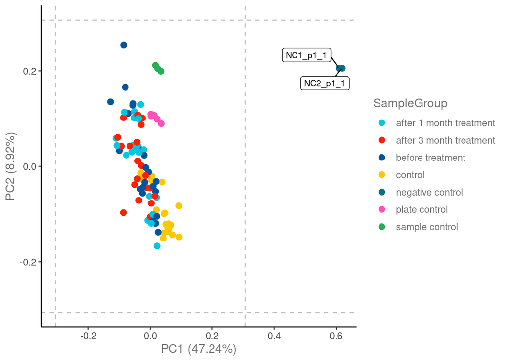

```r
df_qc %>%
    olink_pca_plot(color_g = "SampleGroup", outlierDefX = 3, outlierDefY = 3, outlierLines = TRUE, label_outliers = TRUE)
```

1. Selecting first comparison: control vs. before treatment

```r
df_subs <- df_qc %>%
  filter(SampleGroup %in% c("control", "before treatment"))
```

2. Each sample is measured only once (one hole measurement). But it’s like checking one human for 96 different illnesses. We can’t say that there are 96 humans there!

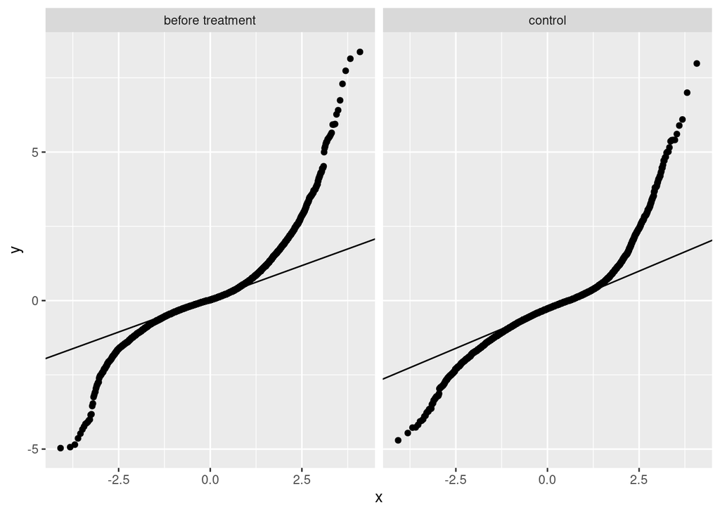

```r
ggplot(df_subs, aes(sample = NPX)) +
  stat_qq() +
  stat_qq_line() +
  facet_wrap(~SampleGroup)
```

3. Checking group sizes:

```r
df_subs %>%
  dplyr::distinct(SampleID, SampleGroup) %>%
  dplyr::count(SampleGroup)
```

```
## # A tibble: 2 × 2
##   SampleGroup          n
##   <chr>            <int>
## 1 before treatment    22
## 2 control             21
```

4. Performing differential expression analysis using Welch t-test:

```r
ttest_results <- olink_ttest(df = df_subs, variable = "SampleGroup")
```

```
## Variable converted from character to factor: SampleGroup
```

```
## 0 assay(s) exhibited assay QC warning. For more information see the AssayQC column.
```

```
## T-test is performed on before treatment - control.
```

Selecting top 10 differentially expressed proteins based on adjusted p-value:

```r
top10_fdr <- ttest_results %>%
  arrange(Adjusted_pval) %>%
  head(10) %>%
  pull(OlinkID)
```

Creating volcano plot to visualize differential expression results:

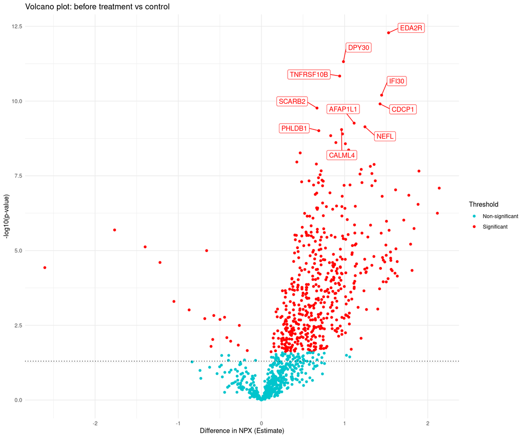

```r
olink_volcano_plot(p.val_tbl = ttest_results, olinkid_list = top10_fdr) +
  scale_color_manual(values = c('turquoise3', 'red')) +
  theme_minimal() +
  labs(title = "Volcano plot: before treatment vs control", x = "Difference in NPX (Estimate)",y = "-log10(p-value)")
```

We will do the same analysis but for after 1 month of treatment vs. before treatment samples:

```r
df_subs_2 <- df_qc %>%
  filter(SampleGroup %in% c("before treatment", "after 1 month treatment"))


df_subs_2_filtered <- df_subs_2 %>%
  filter(SampleGroup %in% c("before treatment", "after 1 month treatment")) %>%
  mutate(PairID = sub("W[12]$", "", SampleID))  # tworzymy identyfikator pary tylko dla W1 i W2
# Upewnij się, że masz kolumnę identyfikującą próbki pacjentów, np. SampleID
# Paired test (sparowane próbki)
ttest_results_2 <- olink_ttest(df_subs_2_filtered, variable = "SampleGroup", pair_id = "PairID")
```

```
## Variable converted from character to factor: SampleGroup
```

```
## 0 assay(s) exhibited assay QC warning. For more information see the AssayQC column.
```

```
## Paired t-test is performed on after 1 month treatment - before treatment.
```

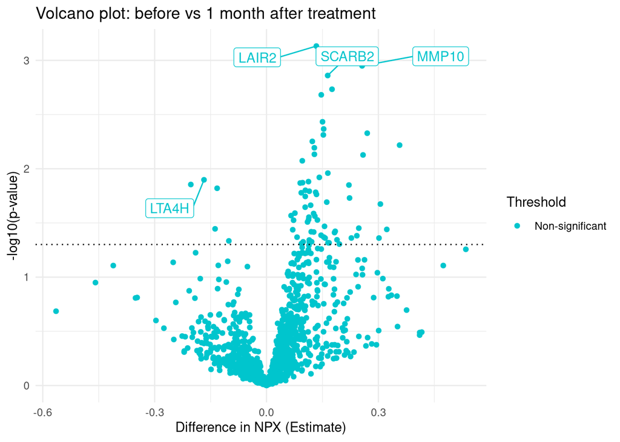

```r
# Weź 20 najbardziej istotnych białek
top20_fdr_2 <- ttest_results_2 %>%
  arrange(Adjusted_pval) %>%
  slice(1:20) %>%
  pull(OlinkID)

# Volcano plot
olink_volcano_plot(p.val_tbl = ttest_results_2, olinkid_list = top20_fdr_2) +
  scale_color_manual(values = c('turquoise3', 'red')) +
  theme_minimal() +
  labs(title = "Volcano plot: before vs 1 month after treatment", x = "Difference in NPX (Estimate)",y = "-log10(p-value)")
```

And for samples before treatment vs. after 3 months of treatment:

```r
df_subs_3 <- df_qc %>%
  filter(SampleGroup %in% c("before treatment", "after 3 month treatment"))


df_subs_3_filtered <- df_subs_3 %>%
  filter(SampleGroup %in% c("before treatment", "after 3 month treatment")) %>%
  mutate(PairID = sub("W[13]$", "", SampleID))
# Upewnij się, że masz kolumnę identyfikującą próbki pacjentów, np. SampleID
# Paired test (sparowane próbki)
ttest_results_3 <- olink_ttest(df_subs_3_filtered, variable = "SampleGroup", pair_id = "PairID")
```

```
## Variable converted from character to factor: SampleGroup
```

```
## 0 assay(s) exhibited assay QC warning. For more information see the AssayQC column.
```

```
## Paired t-test is performed on after 3 month treatment - before treatment.
```

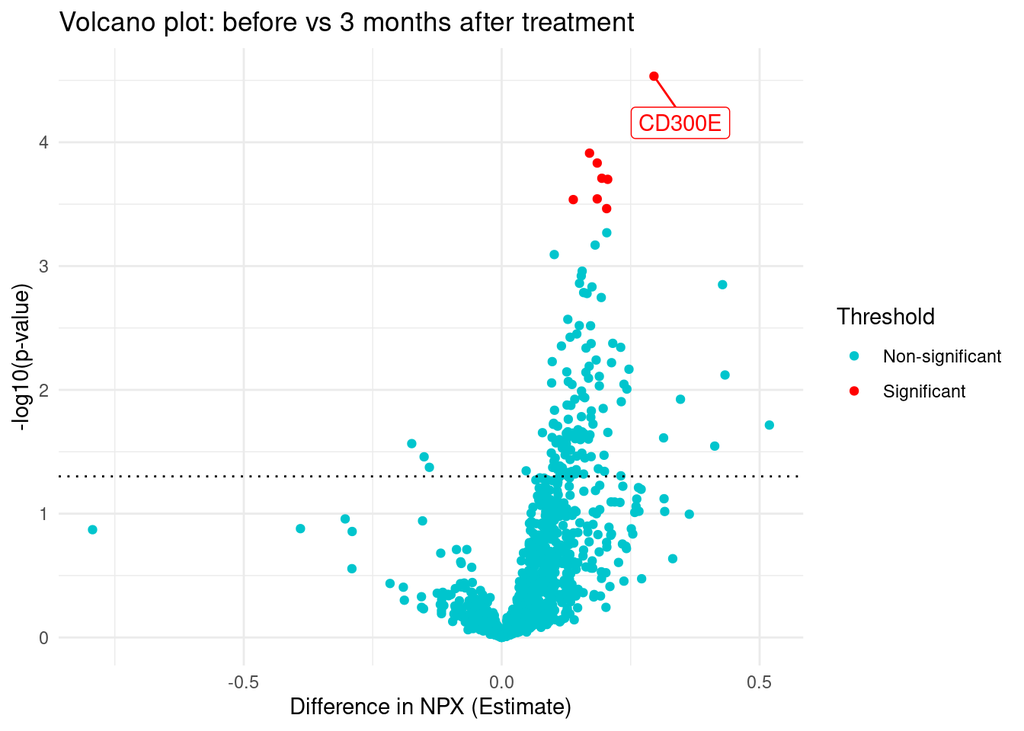

```r
# Weź 20 najbardziej istotnych białek
top20_fdr_3 <- ttest_results_3 %>%
  arrange(Adjusted_pval) %>%
  slice(1:20) %>%
  pull(OlinkID)

# Volcano plot
olink_volcano_plot(p.val_tbl = ttest_results_3, olinkid_list = top20_fdr_3) +
  scale_color_manual(values = c('turquoise3', 'red')) +
  theme_minimal() +
  labs(title = "Volcano plot: before vs 3 months after treatment", x = "Difference in NPX (Estimate)", y = "-log10(p-value)")
```